# Step1. Metacells

In this vignette we generate Metacells, i.e., mini-bulking, to reduce sparseness of and increase the power of the dataset.

# 1 Load libraries

Load the necessary libraries.

```r
library(Seurat)
library(SeuratObject)
library(dplyr)
library(steam)
library(future)
library(ggplot2)
```

# 2 Load data

Load Seurat object.

```r
se <- readRDS("data/mouse_CTX_HPF/se_250_cells_filtered.rds")
se
```

```
## An object of class Seurat
## 15353 features across 9930 samples within 1 assay
## Active assay: RNA (15353 features, 0 variable features)
##  1 layer present: counts
```

```r
head(se[[]])
```

```
##                                        orig.ident nCount_RNA nFeature_RNA
## AAAGATGCAGGGTATG-L8TX_180221_01_F09 SeuratProject      16506         5040
## AACTCAGGTGAGGCTA-L8TX_180221_01_F09 SeuratProject       8345         3282
## ACACCGGGTTGAACTC-L8TX_180221_01_F09 SeuratProject       3209         1664
## ACATCAGAGCGGCTTC-L8TX_180221_01_F09 SeuratProject      14963         5132
## ACCCACTAGTGTGAAT-L8TX_180221_01_F09 SeuratProject      20499         5825
## ACGCCGATCCGGCACA-L8TX_180221_01_F09 SeuratProject      19814         5691
##                                                             sample_name
## AAAGATGCAGGGTATG-L8TX_180221_01_F09 AAAGATGCAGGGTATG-L8TX_180221_01_F09
## AACTCAGGTGAGGCTA-L8TX_180221_01_F09 AACTCAGGTGAGGCTA-L8TX_180221_01_F09
## ACACCGGGTTGAACTC-L8TX_180221_01_F09 ACACCGGGTTGAACTC-L8TX_180221_01_F09
## ACATCAGAGCGGCTTC-L8TX_180221_01_F09 ACATCAGAGCGGCTTC-L8TX_180221_01_F09
## ACCCACTAGTGTGAAT-L8TX_180221_01_F09 ACCCACTAGTGTGAAT-L8TX_180221_01_F09
## ACGCCGATCCGGCACA-L8TX_180221_01_F09 ACGCCGATCCGGCACA-L8TX_180221_01_F09
##                                     donor_sex_id donor_sex_label
## AAAGATGCAGGGTATG-L8TX_180221_01_F09            2               M
## AACTCAGGTGAGGCTA-L8TX_180221_01_F09            2               M
## ACACCGGGTTGAACTC-L8TX_180221_01_F09            2               M
## ACATCAGAGCGGCTTC-L8TX_180221_01_F09            2               M
## ACCCACTAGTGTGAAT-L8TX_180221_01_F09            2               M
## ACGCCGATCCGGCACA-L8TX_180221_01_F09            2               M
##                                     donor_sex_color region_id region_label
## AAAGATGCAGGGTATG-L8TX_180221_01_F09         #ADC4C3        19          ACA
## AACTCAGGTGAGGCTA-L8TX_180221_01_F09         #ADC4C3        19          ACA
## ACACCGGGTTGAACTC-L8TX_180221_01_F09         #ADC4C3        19          ACA
## ACATCAGAGCGGCTTC-L8TX_180221_01_F09         #ADC4C3        19          ACA
## ACCCACTAGTGTGAAT-L8TX_180221_01_F09         #ADC4C3        19          ACA
## ACGCCGATCCGGCACA-L8TX_180221_01_F09         #ADC4C3        19          ACA
##                                     region_color platform_label cluster_order
## AAAGATGCAGGGTATG-L8TX_180221_01_F09      #FFDE17            10X           359
## AACTCAGGTGAGGCTA-L8TX_180221_01_F09      #FFDE17            10X           360
## ACACCGGGTTGAACTC-L8TX_180221_01_F09      #FFDE17            10X           376
## ACATCAGAGCGGCTTC-L8TX_180221_01_F09      #FFDE17            10X           173
## ACCCACTAGTGTGAAT-L8TX_180221_01_F09      #FFDE17            10X           290
## ACGCCGATCCGGCACA-L8TX_180221_01_F09      #FFDE17            10X           261
##                                        cluster_label cluster_color
## AAAGATGCAGGGTATG-L8TX_180221_01_F09    359_CA2-IG-FC       #AD99FF
## AACTCAGGTGAGGCTA-L8TX_180221_01_F09    360_CA2-IG-FC       #765FD2
## ACACCGGGTTGAACTC-L8TX_180221_01_F09        376_Astro       #332F26
## ACATCAGAGCGGCTTC-L8TX_180221_01_F09 173_L2/3 IT ProS       #21EC1D
```

[output cut: 225 more lines]

```
## ACGCCGATCCGGCACA-L8TX_180221_01_F09                   #5BC6A1
##                                     cortical_layer_label cortical_layer_order
## AAAGATGCAGGGTATG-L8TX_180221_01_F09                   NA                    1
## AACTCAGGTGAGGCTA-L8TX_180221_01_F09                   NA                    1
## ACACCGGGTTGAACTC-L8TX_180221_01_F09                   NA                    1
## ACATCAGAGCGGCTTC-L8TX_180221_01_F09                   NA                    1
## ACCCACTAGTGTGAAT-L8TX_180221_01_F09                   NA                    1
## ACGCCGATCCGGCACA-L8TX_180221_01_F09                   NA                    1
##                                     cortical_layer_color percent.mt percent.rb
## AAAGATGCAGGGTATG-L8TX_180221_01_F09              #FF7373   3.259421   2.623289
## AACTCAGGTGAGGCTA-L8TX_180221_01_F09              #FF7373   2.612343   2.156980
## ACACCGGGTTGAACTC-L8TX_180221_01_F09              #FF7373   3.864132   0.529760
## ACATCAGAGCGGCTTC-L8TX_180221_01_F09              #FF7373   5.453452   2.840340
## ACCCACTAGTGTGAAT-L8TX_180221_01_F09              #FF7373   2.180594   2.517196
## ACGCCGATCCGGCACA-L8TX_180221_01_F09              #FF7373   3.835672   2.139901
```

Check the number of cells per cell type for the cluster annotation you want to create Metacells from. Please note that when creating Metacells, all annotated classes with less than 50 will be excluded using default settings.

```r
table(se$subclass_label)
```

```
##
##           Astro        CA1-ProS       CA2-IG-FC             CA3            Car3
##             216             250             248             248             246
##              CR          CT SUB              DG            Endo      L2 IT ENTl
##             246             249             250             246             250
##      L2 IT ENTm     L2/3 IT CTX    L2/3 IT ENTl     L2/3 IT PPP     L2/3 IT RHP
##             250             249             248             248             249
##       L3 IT ENT      L4 RSP-ACA     L4/5 IT CTX       L5 IT CTX          L5 PPP
##             250             232             250             249             248
##       L5 PT CTX L5/6 IT TPE-ENT     L5/6 NP CTX       L6 CT CTX       L6 IT CTX
##             237             244             250             249             249
##      L6 IT ENTl         L6b CTX      L6b/CT ENT           Lamp5           Meis2
##             250             246             249             250              19
##       Micro-PVM          NP PPP          NP SUB           Oligo           Pvalb
##             211             250             250             235             243
##        SMC-Peri            Sncg             Sst       Sst Chodl        SUB-ProS
##             204             246             250             248             247
##             Vip            VLMC
##             245             136
```

Check counts

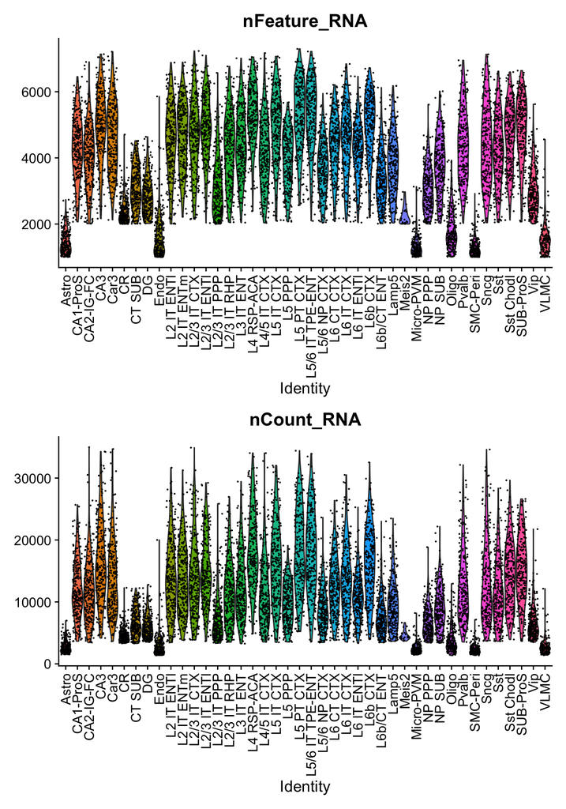

```r
p <- VlnPlot(se, features = c("nFeature_RNA", "nCount_RNA"), ncol = 1, group.by = "subclass_label")
p & theme(axis.text.x = element_text(angle = 90, hjust = 1, vjust = 0.5))
```

# 3 Generat Metacell clusters

Here we want to generate Metacells from the cluster annotation ‘subclass_label’. The generate_metacell_clusters function subsets all selected clusters into separate Seurat objects and then uses NormalizeData, FindVariableFeatures, ScaleData, RunPCA and FindNeighbors on each and saving them to a list. For each Seurat object in the list the optimal clustering resolution setting is tested by iterating using the FindClusters function, starting at a user given initial resolution (initial_resolution) and moving by 0.1 until the average number of cells per cluster (i.e., the Metacell) is > 10 (num_cells_per_metacell). The generate_metacell_clusters iterations then reduces the clustering resolution with 0.1 if the average number of cells per cluster (i.e., the Metacell) is < 10 (num_cells_per_metacell), and then stops.

Please note that if the desired number of average cells per cluster is not possible the reach, the function will stall out. If that happens try using +/- 1 desired number of average cells per cluster and re-run.

```r
plan("sequential")

metacells <- generate_metacell_clusters(
   se = se,
   cluster_anno = "subclass_label",
   num_cells_per_metacell = 10,
   pca_dims = 10,
   initial_resolution = 0.1
 )
```

```
## [1] "Removed cell types with too few cells:"
## [1] "Meis2"
```

```
##
## Processing cell type: CA2-IG-FC
```

```
##
## Processing cell type: Astro
```

```
##
## Processing cell type: L2/3 IT RHP
```

```
##
## Processing cell type: L6 CT CTX
```

```
##
## Processing cell type: L4 RSP-ACA
```

```
##
## Processing cell type: Sst
```

```
##
## Processing cell type: Sncg
```

```
##
## Processing cell type: L2/3 IT PPP
```

```
##
## Processing cell type: L5 IT CTX
```

```
##
## Processing cell type: L4/5 IT CTX
```

```
##
## Processing cell type: L6 IT CTX
```

```
##
## Processing cell type: L5/6 NP CTX
```

```
##
## Processing cell type: Sst Chodl
```

```
##
## Processing cell type: L6b CTX
```

```
##
## Processing cell type: CR
```

```
##
## Processing cell type: Lamp5
```

```
##
## Processing cell type: Micro-PVM
```

```
##
## Processing cell type: L2/3 IT CTX
```

```
##
## Processing cell type: Vip
```

```
##
## Processing cell type: L5 PT CTX
```

```
##
## Processing cell type: SMC-Peri
```

```
##
## Processing cell type: Pvalb
```

```
##
## Processing cell type: Oligo
```

```
##
## Processing cell type: L5/6 IT TPE-ENT
```

```
##
## Processing cell type: VLMC
```

```
##
## Processing cell type: Endo
```

```
##
## Processing cell type: NP SUB
```

```
##
## Processing cell type: Car3
```

```
##
## Processing cell type: L2/3 IT ENTl
```

```
##
## Processing cell type: L2 IT ENTl
```

```
##
## Processing cell type: L6 IT ENTl
```

```
##
## Processing cell type: L6b/CT ENT
```

```
##
## Processing cell type: L3 IT ENT
```

```
##
## Processing cell type: CT SUB
```

```
##
## Processing cell type: L2 IT ENTm
```

```
##
## Processing cell type: NP PPP
```

```
##
## Processing cell type: L5 PPP
```

```
##
## Processing cell type: DG
```

```
##
## Processing cell type: CA1-ProS
```

```
##
## Processing cell type: CA3
```

```
##
## Processing cell type: SUB-ProS
```

Lets investigate the output and look at the distribution of the number of cells per cluster that we will aggregate into Metacells. All look good to go, watch out for extremely skewed distributions. If that happens, investigate if other QC filtering settings after subsampling might help.

```
## [1] "Number of clusters for cell type Astro : 17"
## [1] "Cluster distribution:"
##
##  0  1  2  3  4  5  6  7  8  9 10 11 12 13 14 15 16
## 38 25 19 17 14 14 14 13 13 11  8 11  6  4  3  3  3
```

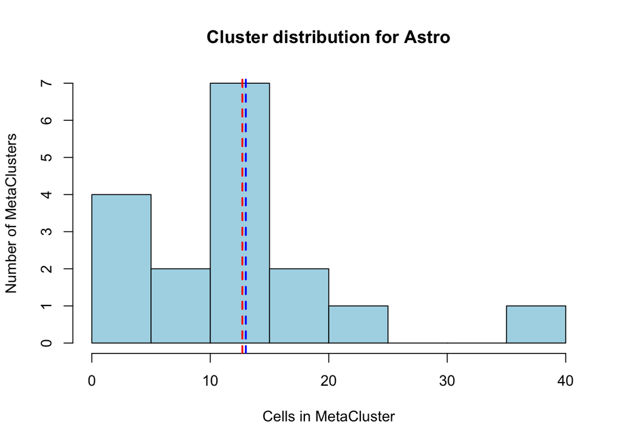

```
## [1] "________________________________________________________________"
## [1] "Number of clusters for cell type CA1-ProS : 25"
## [1] "Cluster distribution:"
##
##  0  1  2  3  4  5  6  7  8  9 10 11 12 13 14 15 16 17 18 19 20 21 22 23 24
## 23 19 19 17 17 17 16 14 13 13 12 10 10  7  6  5  4  5  4  4  3  3  4  3  2
```

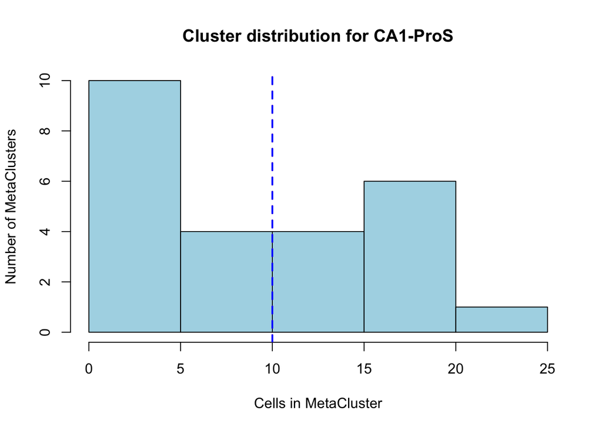

```
## [1] "________________________________________________________________"
## [1] "Number of clusters for cell type CA2-IG-FC : 24"
## [1] "Cluster distribution:"
##
##  0  1  2  3  4  5  6  7  8  9 10 11 12 13 14 15 16 17 18 19 20 21 22 23
## 23 22 22 21 18 16 14 13 11 10 10 12 10  7  6  5  5  5  4  4  3  2  3  2
```

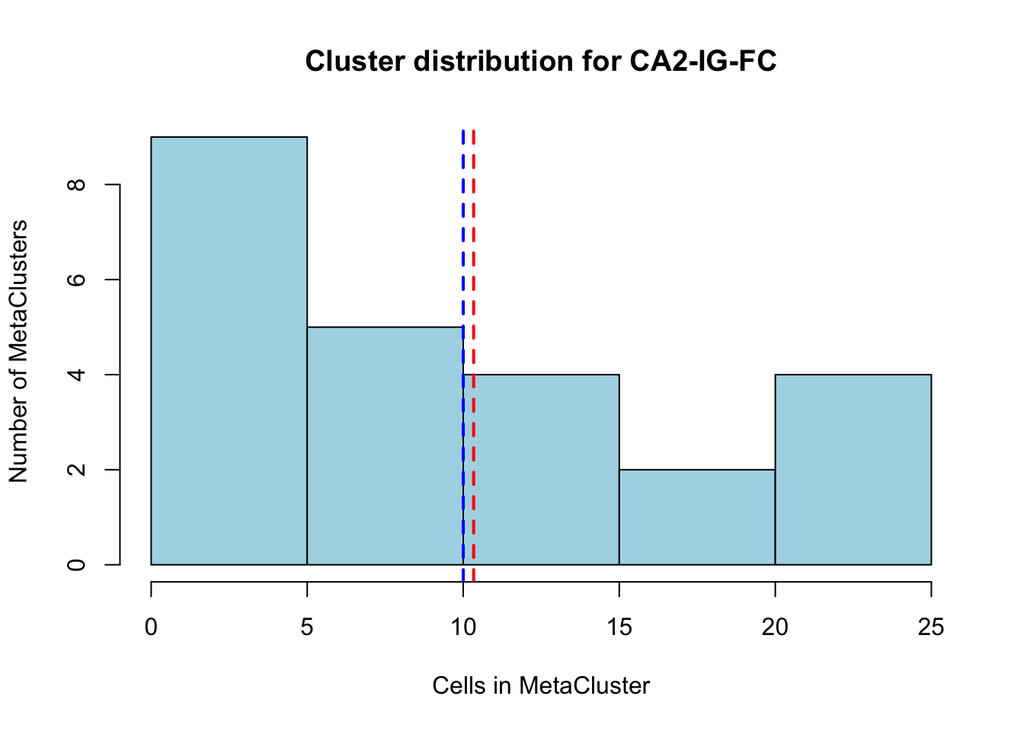

```
## [1] "________________________________________________________________"
## [1] "Number of clusters for cell type CA3 : 24"
## [1] "Cluster distribution:"
##
##  0  1  2  3  4  5  6  7  8  9 10 11 12 13 14 15 16 17 18 19 20 21 22 23
## 24 23 19 17 18 15 14 14 12 12 10 10  9  8  7  7  7  5  4  3  2  2  3  3
```

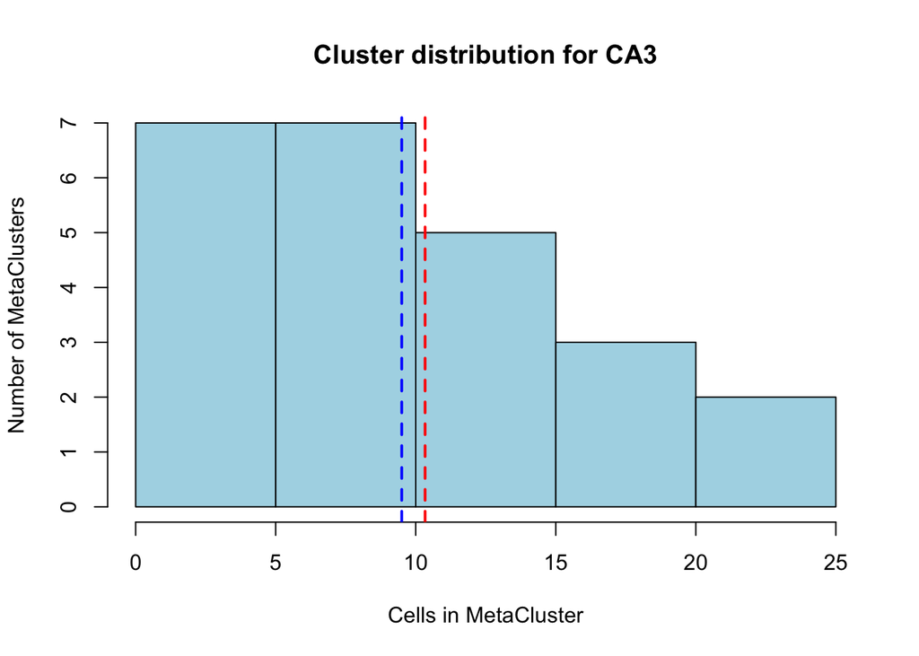

```
## [1] "________________________________________________________________"
## [1] "Number of clusters for cell type Car3 : 24"
## [1] "Cluster distribution:"
##
##  0  1  2  3  4  5  6  7  8  9 10 11 12 13 14 15 16 17 18 19 20 21 22 23
## 23 21 18 17 16 15 15 14 14 14  9  8  9  8  7  7  5  8  4  4  3  3  2  2
```

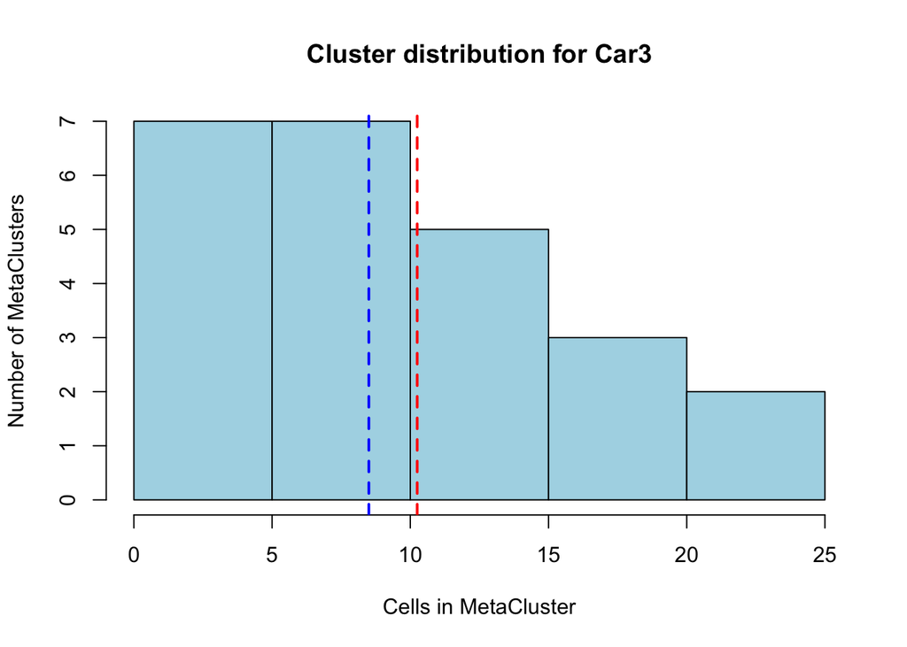

```
## [1] "________________________________________________________________"
## [1] "Number of clusters for cell type CR : 24"
## [1] "Cluster distribution:"
##
##  0  1  2  3  4  5  6  7  8  9 10 11 12 13 14 15 16 17 18 19 20 21 22 23
## 37 22 21 19 18 16 16 12 10 10  8  7  8  7  5  5  4  3  3  3  4  3  3  2
```

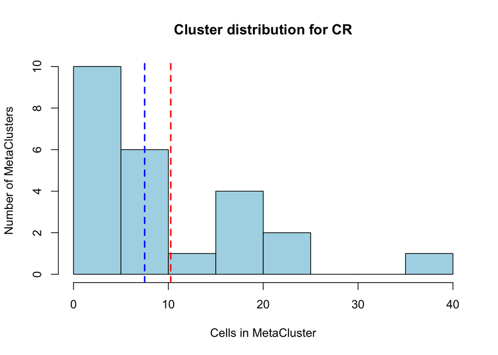

```
## [1] "________________________________________________________________"
## [1] "Number of clusters for cell type CT SUB : 21"
## [1] "Cluster distribution:"
##
##  0  1  2  3  4  5  6  7  8  9 10 11 12 13 14 15 16 17 18 19 20
## 32 24 23 24 17 13 12 11 10 10 10 10  9  8  7  7  6  8  4  2  2
```

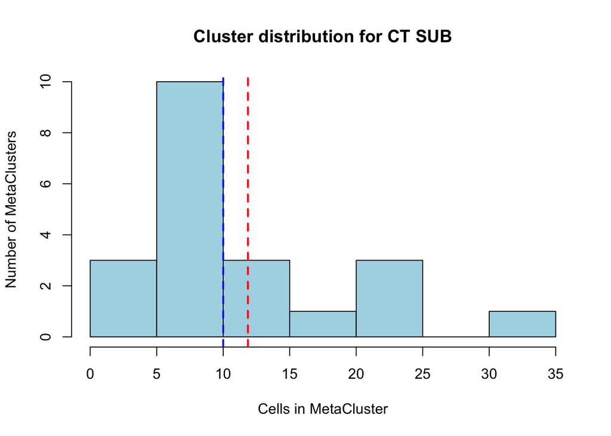

```
## [1] "________________________________________________________________"
## [1] "Number of clusters for cell type DG : 24"
## [1] "Cluster distribution:"
##
##  0  1  2  3  4  5  6  7  8  9 10 11 12 13 14 15 16 17 18 19 20 21 22 23
## 32 27 22 21 17 17 15 13 11  7  7  7  7  6  6  8  6  7  4  2  2  2  2  2
```

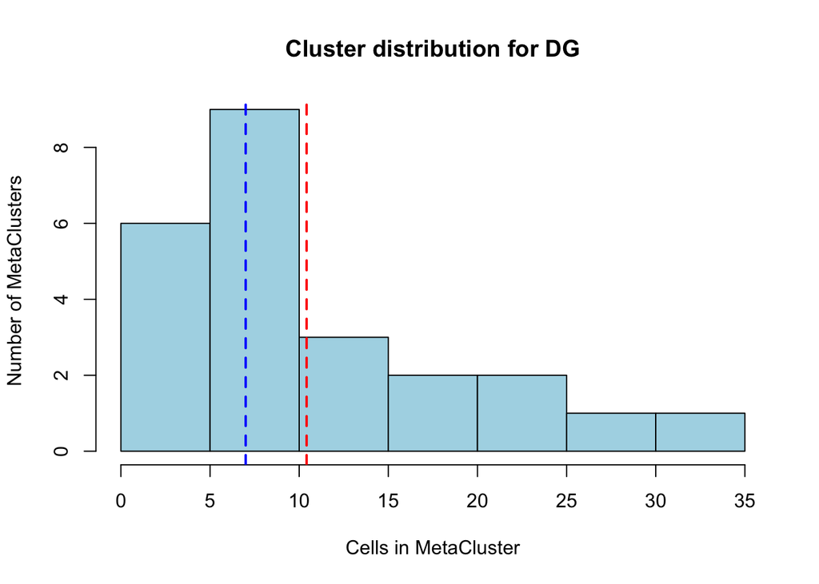

```
## [1] "________________________________________________________________"
## [1] "Number of clusters for cell type Endo : 23"
## [1] "Cluster distribution:"
##
##  0  1  2  3  4  5  6  7  8  9 10 11 12 13 14 15 16 17 18 19 20 21 22
## 29 26 24 18 16 14 13 13 12  9  9  8  8  7  6  7  6  6  5  3  2  2  3
```

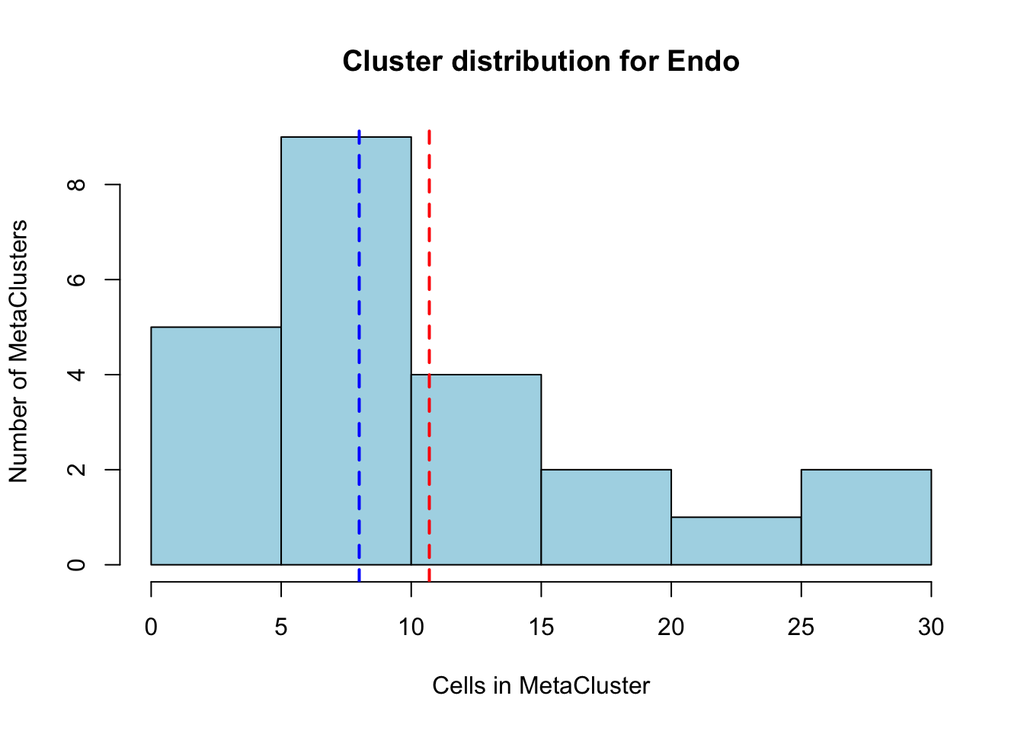

```
## [1] "________________________________________________________________"
## [1] "Number of clusters for cell type L2 IT ENTl : 25"
## [1] "Cluster distribution:"
##
##  0  1  2  3  4  5  6  7  8  9 10 11 12 13 14 15 16 17 18 19 20 21 22 23 24
## 24 19 18 16 16 16 15 13 13 10 10 10 10  9  8  6  6  6  6  5  4  3  3  2  2
```

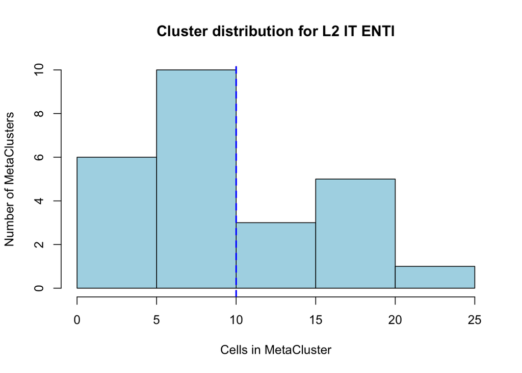

```
## [1] "________________________________________________________________"
## [1] "Number of clusters for cell type L2 IT ENTm : 23"
## [1] "Cluster distribution:"
##
##  0  1  2  3  4  5  6  7  8  9 10 11 12 13 14 15 16 17 18 19 20 21 22
## 28 21 21 19 19 16 16 14 14 11 11 11  9  7  6  5  5  3  3  5  2  2  2
```

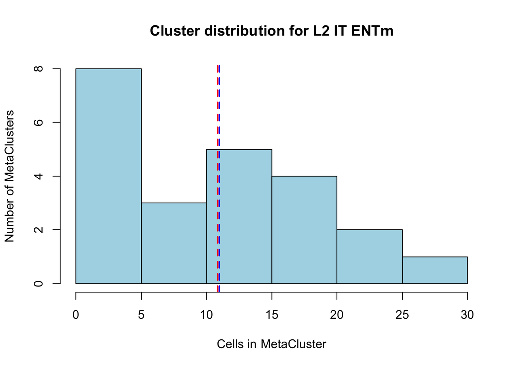

```
## [1] "________________________________________________________________"
## [1] "Number of clusters for cell type L2/3 IT CTX : 23"
## [1] "Cluster distribution:"
##
##  0  1  2  3  4  5  6  7  8  9 10 11 12 13 14 15 16 17 18 19 20 21 22
## 27 22 20 20 20 17 17 12 11 11 10 11 10  9  7  6  3  3  3  3  3  2  2
```

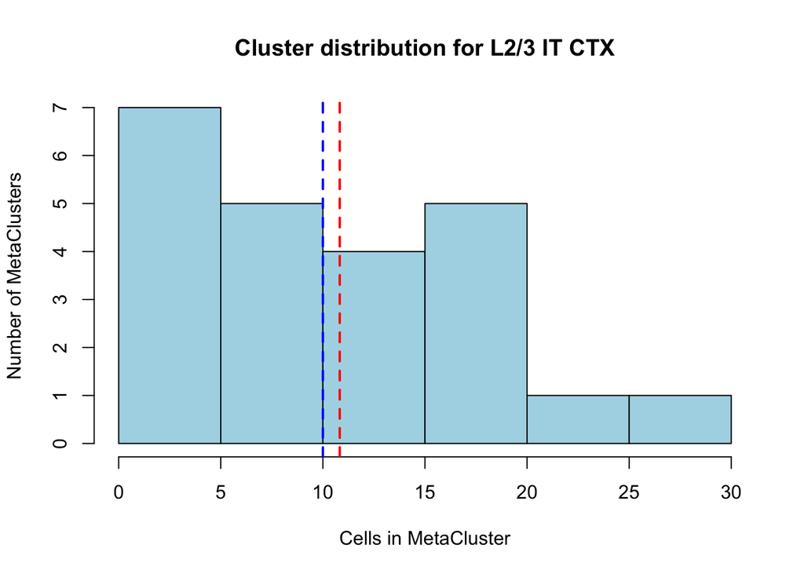

```
## [1] "________________________________________________________________"
## [1] "Number of clusters for cell type L2/3 IT ENTl : 24"
## [1] "Cluster distribution:"
##
##  0  1  2  3  4  5  6  7  8  9 10 11 12 13 14 15 16 17 18 19 20 21 22 23
## 24 24 23 22 18 14 13 13 11 11 11 12  6  6  5  5  5  5  4  3  3  4  3  3
```

[29 more figures not shown]

```
## [1] "________________________________________________________________"
```

```r
# Count how many cells per type
cell_counts <- table(se$subclass_label)

# Keep only those with at least 50 cells
valid_cell_types <- names(cell_counts[cell_counts >= 50])

# Extract only valid cell types present in the data
cell_types <- intersect(unique(se$subclass_label), valid_cell_types)

# Sort alphabetically
sorted_indices <- order(cell_types)
cell_types <- cell_types[sorted_indices]
metacells <- metacells[sorted_indices]  # reorder metacells to match

# Check clustering and print number of clusters for each cell type subset
invisible(lapply(1:length(metacells), function(i) {
    ct_subset <- metacells[[i]]  # Get the current cell type subset

    # Get the number of clusters (unique values in the 'seurat_clusters' column)
    num_clusters <- length(unique(ct_subset$seurat_clusters))

    # Print the number of clusters for the current cell type
    print(paste("Number of clusters for cell type", cell_types[i], ":", num_clusters))

    # Size of each cluster (how many cells per cluster)
    print(paste("Cluster distribution:"))
    cluster_distribution <- table(ct_subset$seurat_clusters)
    print(cluster_distribution)

    # Plot the histogram of the cluster distribution
    hist(cluster_distribution,
         main = paste("Cluster distribution for", cell_types[i]),
         xlab = "Cells in MetaCluster",
         ylab = "Number of MetaClusters",
         col = "lightblue",
         border = "black")

    # Calculate the mean and median of the cluster distribution
    mean_cluster_size <- mean(cluster_distribution)
    median_cluster_size <- median(cluster_distribution)

    # Add a red line at the mean and blue to the median
    abline(v = mean_cluster_size, col = "red", lwd = 2, lty = 2)
    abline(v = median_cluster_size, col = "blue", lwd = 2, lty = 2)

    print("________________________________________________________________")
}))
```

# 4 Aggregate Metacell clusters

Now, let’s aggregates the expression data across clusters (Metacells) by summing counts within each cluster of each cell type, and create a Metacell Seurat object!

```r
metacell_seurat <- aggregate_metacells(metacells, cluster_col = "subclass_label")
table(metacell_seurat$subclass_label)
```

```
##
##           Astro        CA1-ProS       CA2-IG-FC             CA3            Car3
##              17              25              24              24              24
##              CR          CT SUB              DG            Endo      L2 IT ENTl
##              24              21              24              23              25
##      L2 IT ENTm     L2/3 IT CTX    L2/3 IT ENTl     L2/3 IT PPP     L2/3 IT RHP
##              23              23              24              24              24
##       L3 IT ENT      L4 RSP-ACA     L4/5 IT CTX       L5 IT CTX          L5 PPP
##              23              23              23              23              22
##       L5 PT CTX L5/6 IT TPE-ENT     L5/6 NP CTX       L6 CT CTX       L6 IT CTX
##              23              24              25              24              24
##      L6 IT ENTl         L6b CTX      L6b/CT ENT           Lamp5       Micro-PVM
##              25              23              22              23              21
##          NP PPP          NP SUB           Oligo           Pvalb        SMC-Peri
##              25              24              23              23              19
##            Sncg             Sst       Sst Chodl        SUB-ProS             Vip
##              24              23              24              24              24
##            VLMC
##              13
```

```r
metacell_seurat
```

```
## An object of class Seurat
## 15353 features across 943 samples within 1 assay
## Active assay: RNA (15353 features, 0 variable features)
##  41 layers present: counts.1.1.1.1.1.1.1.1.1.1.1.1.1.1.1.1.1.1.1.1.1.1.1.1.1.1.1.1.1.1.1.1.1.1.1.1.1.1.1.1, counts.2, counts.2.1, counts.2.1.1, counts.2.1.1.1, counts.2.1.1.1.1, counts.2.1.1.1.1.1, counts.2.1.1.1.1.1.1, counts.2.1.1.1.1.1.1.1, counts.2.1.1.1.1.1.1.1.1, counts.2.1.1.1.1.1.1.1.1.1,…
```

Check results

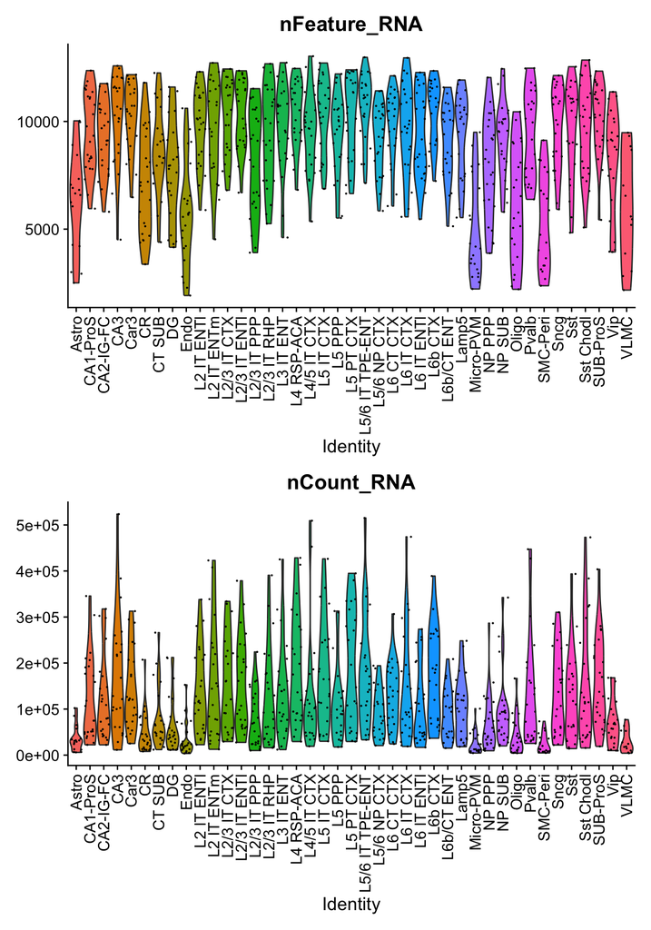

```r
p <- VlnPlot(metacell_seurat, features = c("nFeature_RNA", "nCount_RNA"), ncol = 1, group.by = "subclass_label")
p & theme(axis.text.x = element_text(angle = 90, hjust = 1, vjust = 0.5))
```

Save the Metacell Seurat object for downstream analysis!

```r
saveRDS(metacell_seurat, file = "data/mouse_CTX_HPF/se_250_cells_filtered_Metacell.rds")
```

Normalize data with SCTransform.

```r
options(future.globals.maxSize = 4 * 1024^3)
metacell_seurat
metacell_seurat <- JoinLayers(metacell_seurat)
metacell_seurat
metacell_seurat_normalized <- SCTransform(metacell_seurat,assay = "RNA",return.only.var.genes = T)
```

```r
metacell_seurat_normalized
```

```
## An object of class Seurat
## 30706 features across 943 samples within 2 assays
## Active assay: SCT (15353 features, 3000 variable features)
##  3 layers present: counts, data, scale.data
##  1 other assay present: RNA
```

Save the normalized Metacell Seurat object for downstream analysis!

```r
saveRDS(metacell_seurat_normalized, file = "data/mouse_CTX_HPF/se_250_cells_filtered_Metacell_normalized.rds")
```